# Assigment - Naive Bayes DIY

Minh Dung Pham- Author

01 April, 2021

## Business Understanding

In this case we need to use NB to detect the hate speech from data which is collected from REDDIT.

## Data Understanding

First we need to import data from github.

```r
url <- "https://raw.githubusercontent.com/HAN-M3DM-Data-Mining/assignments/master/datasets/NB-reddit-hate-speech.csv"
NBdataraw <- read_csv(url)
head(NBdataraw,5)
```

| id | text | hate_speech_idx | response |
| --- | --- | --- | --- |
| 1. e8q18lf\n2. \te8q9w5s\n3. \t\te8qbobk\n4. \t\t\te8qfn91\n | 1. A subsection of retarded Hungarians? Ohh boy. brace for a livid Bulbasaur coming in here trying to hate a hole in some of her stupider countrymen.\n2. \tHiii. Just got off work. 444 is mainly the t… | [1] | ["I don't see a reason why it's okay to insult others based on their ethnic background.", 'Language people. You can express your ire respectfully and we insist that you do so. Thank you.', 'Stop using… |
| 1. e9c6naz\n2. \te9d03a5\n3. \t\te9d8e4d\n | 1. > "y'all hear sumn?" by all means I live in a small town rn (for work). 5k people here, originally a mining community. No one is protesting here. Nobody mentioned the protest today. Nobody here car… | [3] | ['Persons with disabilities is the accepted term. Consider this a first warning. We appreciate your understanding and cooperation.', 'Avert from using mental impairments as a way to insult users.'] |
| 1. e84rl2i\n2. \te84w60l\n3. \t\te8544rn\n4. \t\t\te85ifut\n5. \t\t\t\te85nvr7\n6. \t\t\t\t\te85t0ci\n7. \t\t\t\t\t\te863k57\n8. \t\t\t\t\t\t\te87gg63\n9. \t\t\t\t\t\t\t\te886ajt\n10. \t\t\t\t\t\t\t\t… | 1. wouldn't the defenders or whatever they are as a group be the most diverse group ? Since you know it has a blind dude , orphan , black man , woman and all of their supporting cast ? &#x200B; I also… | n/a | n/a |
| 1. e7kq72n\n2. \te7m24ar\n | 1. Because the Japanese aren't retarded and know that *fictional characters* aren't owed anything, much less dignity.\n2. \tJapan doesn't shy* away from a lot of things. Male characters smack around w… | [1] | ["It's not right for anyone of any gender to be hurting the opposite gender, whether it be male or female.", 'We ask that you refrain from using such terms to express your opinions of others intellige… |
| 1. e7hdgoh\n2. \te7iyj6a\n3. \t\te7j6iho\n4. \t\t\te7m2412\n5. \t\t\t\te7m5t9f\n6. \t\t\t\t\te7mphok\n7. \t\t\t\t\t\te7muj9q\n8. \t\t\t\t\t\t\te7mz1vg\n | 1. That might be true if we didn't have an example of a whole segment of the US population blindly screaming for the head of a man based on accusations from a demonstrably unreliable witness about an … | [2, 3] | ["You shouldn't be bringing up sensitive topics. People have went through these kinds of things. To take them lightly is not acceptable.", 'Reddit is for everyone people we ask that you refrain from s… |

We only need the text and the hate speed idc therefore we will remove the unneeded. WE also need to change the hate_speech_idx into factor which only contains “normal” and “hate”.

```r
NBdata<-NBdataraw[-c(1,4)]
NBdata$hate_speech_idx<- ifelse(NBdata$hate_speech_idx == "n/a", "normal", "hate")
NBdata$hate_speech_idx <- NBdata$hate_speech_idx %>% factor
class(NBdata$hate_speech_idx)
```

```
[1] "factor"
```

Lastly, I create the world could for visualization to find out which is most occur word.

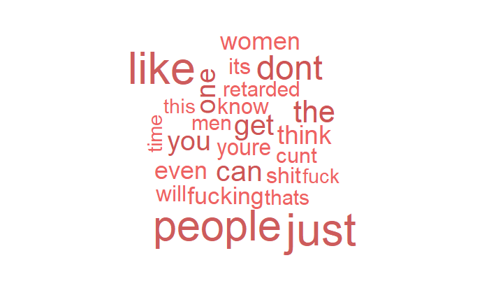

```r
hate <-  filter(NBdata,hate_speech_idx == "hate")
normal <- filter(NBdata,hate_speech_idx == "normal")

wordcloud(hate$text, max.words = 25, scale = c(4, 0.8), colors= c("indianred1","indianred2","indianred3","indianred"))
```

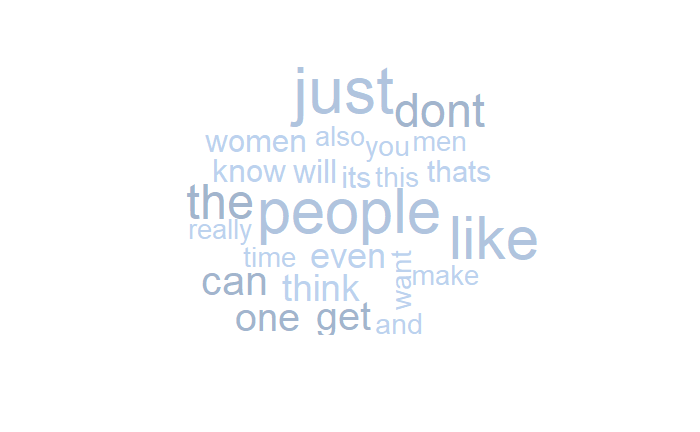

```r
wordcloud(normal$text, max.words = 25, scale = c(4, 0.8), colors= c("lightsteelblue1","lightsteelblue2","lightsteelblue3","lightsteelblue"))
```

## Data Preparation

In this step, I will crease a corpus which is collection of text document.

```r
rawCorpus <- Corpus(VectorSource(NBdata$text))
inspect(rawCorpus[1:3])
```

```
<<SimpleCorpus>>
Metadata:  corpus specific: 1, document level (indexed): 0
Content:  documents: 3

[1] 1. A subsection of retarded Hungarians? Ohh boy. brace for a livid Bulbasaur coming in here trying to hate a hole in some of her stupider countrymen.\n2. \tHiii. Just got off work. 444 is mainly the typa guys you imagine writing for US stupid sites, but basically they just try to fit in with the…
[2] 1. > "y'all hear sumn?"  by all means I live in a small town rn (for work). 5k people here, originally a mining community. No one is protesting here. Nobody mentioned the protest today. Nobody here cares, they're busy loving their family and working hard.  Thank god for the electoral college. Li…
[3] 1. wouldn't the defenders or whatever they are as a group be the most diverse group ? Since you know it has a blind dude ,  orphan , black man , woman  and all of their supporting cast ?   &#x200B;  I also believe all the Marvel stuff is going to get canceled on Netflix because next year Disney …
```

Then I eliminate the unneeded items like number, punctuation, common words and white space. I also change all the word to lowercase.we can see the different between the raw and the cleaned version

```r
rawCorpus <- Corpus(VectorSource(NBdata$text))
cleanCorpus <- rawCorpus %>% tm_map(tolower) %>% tm_map(removeNumbers)
cleanCorpus <- cleanCorpus %>% tm_map(tolower) %>% tm_map(removeWords, stopwords()) %>% tm_map(removePunctuation)
cleanCorpus <- cleanCorpus %>% tm_map(stripWhitespace)
tibble(Raw = rawCorpus$content[1:3], Clean = cleanCorpus$content[1:3])
```

| Raw | Clean |
| --- | --- |
| 1. A subsection of retarded Hungarians? Ohh boy. brace for a livid Bulbasaur coming in here trying to hate a hole in some of her stupider countrymen.\n2. \tHiii. Just got off work. 444 is mainly the t… | subsection retarded hungarians ohh boy brace livid bulbasaur coming trying hate hole stupider countrymen hiii just got work mainly typa guys imagine writing us stupid sites basically just try fit west… |
| 1. > "y'all hear sumn?" by all means I live in a small town rn (for work). 5k people here, originally a mining community. No one is protesting here. Nobody mentioned the protest today. Nobody here car… | y hear sumn means live small town rn work k people originally mining community one protesting nobody mentioned protest today nobody cares busy loving family working hard thank god electoral college li… |
| 1. wouldn't the defenders or whatever they are as a group be the most diverse group ? Since you know it has a blind dude , orphan , black man , woman and all of their supporting cast ? &#x200B; I also… | defenders whatever group diverse group since know blind dude orphan black man woman supporting cast xb also believe marvel stuff going get canceled netflix next year disney launching streaming platfor… |

Now, I will transform the data into matrix.

```r
cleanDTM <- cleanCorpus %>% DocumentTermMatrix
inspect(cleanDTM)
```

```
<<DocumentTermMatrix (documents: 5020, terms: 36551)>>
Non-/sparse entries: 368956/183117064
Sparsity           : 100%
Maximal term length: 353
Weighting          : term frequency (tf)
Sample             :
      Terms
Docs   can even get just like one people think will women
  1182  17   14  20   17   24  24     13    12    4     6
  1257   7    9   3    7   14   2     14     9    6     0
  1296   8   19  17   11   13   8     37    15   10     7
  1401   6    6   7   18   18   3     18    17    7     0
  1413  17   10   4    6   12   4     10     4    6    14
  2608  22    4   4    7    9   6     12     8    8     0
  3764  20    6  11    9   14   3     23     4   14     0
  3767  22    4   6    9    8   1      5     5    9    47
  3777   2    9   1    9   12  20     27     5    5     0
  4356  15   13   9   12    7   6     22    11    6    38
```

Then I split the data into test set and train set with the proportion 75-25.

```r
set.seed(1234)
trainIndex1 <- createDataPartition(NBdata$hate_speech_idx, p = .75,
                                  list = FALSE,
                                  times = 1,)
head(trainIndex,10)
```

[output not shown]

```r
# Apply split indices to DF
trainDF <- NBdata[trainIndex1, ]

testDF <- NBdata[-trainIndex1, ]
# Apply split indices to Corpus
trainCorpus <- cleanCorpus[trainIndex1]
testCorpus <- cleanCorpus[-trainIndex1]

# Apply split indices to DTM
trainDTM <- cleanDTM[trainIndex1, ]
testDTM <- cleanDTM[-trainIndex1, ]
```

After that , I eliminate the low frequencies word. Finally, I will transform the counts into a factor to find out whether the word appears in the document or not. We’ll first build our own function for this and then apply it to each column in the DTM.

```r
freqWords <- trainDTM %>% findFreqTerms(10)
trainDTM <-  DocumentTermMatrix(trainCorpus, list(dictionary = freqWords))
testDTM <-  DocumentTermMatrix(testCorpus, list(dictionary = freqWords))

convert_counts <- function(x) {
  x <- ifelse(x > 0, 1, 0) %>% factor(levels = c(0,1), labels = c("No", "Yes"))
}

nColsDTM <- dim(trainDTM)[2]
trainDTM <- apply(trainDTM, MARGIN = 2, convert_counts)
testDTM <- apply(testDTM, MARGIN = 2, convert_counts)

head(trainDTM[,1:10])
```

```
    Terms
Docs asked based busy  can   cares check clue  college comment community
   1 "Yes" "Yes" "Yes" "Yes" "Yes" "Yes" "Yes" "Yes"   "Yes"   "Yes"
   2 "No"  "No"  "No"  "Yes" "No"  "No"  "No"  "No"    "No"    "No"
   3 "No"  "No"  "No"  "No"  "No"  "No"  "No"  "No"    "No"    "No"
   4 "No"  "Yes" "No"  "Yes" "No"  "No"  "No"  "No"    "No"    "No"
   5 "No"  "No"  "No"  "No"  "No"  "No"  "No"  "No"    "No"    "No"
   6 "No"  "Yes" "No"  "Yes" "No"  "No"  "No"  "No"    "No"    "Yes"
```

## Modeling and Evaluation

I will start training our model and evaluate against our test dataset using NB and Use a confusion matrix we can analyze the performance of our model.

```r
nbayesModel <-  naiveBayes(trainDTM, trainDF$hate_speech_idx, laplace = 1)

predVec <- predict(nbayesModel, testDTM)
confusionMatrix(predVec, testDF$hate_speech_idx, positive = "hate", dnn = c("Prediction", "True"))
```

```
Confusion Matrix and Statistics

          True
Prediction hate normal
    hate    687    147
    normal  274    146

               Accuracy : 0.6643
                 95% CI : (0.6374, 0.6904)
    No Information Rate : 0.7663
    P-Value [Acc > NIR] : 1

                  Kappa : 0.1853

 Mcnemar's Test P-Value : 8.207e-10

            Sensitivity : 0.7149
            Specificity : 0.4983
         Pos Pred Value : 0.8237
         Neg Pred Value : 0.3476
             Prevalence : 0.7663
         Detection Rate : 0.5478
   Detection Prevalence : 0.6651
      Balanced Accuracy : 0.6066

       'Positive' Class : hate
```